# 马尔可夫链蒙特卡罗（MCMC）方法及其应用

黄佳谊

# 1 简介

假设现有一个概率分布$f(\cdot)$，目标是对其进行随机抽样，或是求函数关于该概率分布的数学期望。可以采用传统的蒙特卡罗法，如接受-拒绝法、重要性抽样法等。也可以使用**马尔可夫链蒙特卡罗方法**，该方法更适合于随机变量是多元的、密度函数是非标准形式的、随机变量各分量不独立等情况。

**马尔可夫链蒙特卡罗（MCMC）方法**主要是基于Metropolis等人和Hastings提出的蒙特卡罗积分法的一般框架。该方法根据目标密度$f(\cdot)$，通过MCMC方法构造一个具有平稳分布$f(\cdot)$的Markov链，然后运行充分长的时间直到该链（近似）收敛于它的平稳分布。

# 2 MCMC方法需要的定理

为此，需要关于Markov链及蒙特卡罗方法的定义及定理（关于Markov链的一般性介绍参见《随机过程》，Ross）。

**定义1（连续状态Markov链）** 称$X=\{X_0,X_1,\dots,X_t,\dots\}$为连续状态Markov链，若随机变量$X_t(t=0,1,2,\dots)$定义在连续状态空间$X$，转移概率分布由转移核（transition kernel）表示。$\forall x\in X,A\subset X$，转移核$P(x,A)$定义为
$$P(x,A)=\int_Ap(x,y)dy$$
其中$p(x,\cdot)$是概率转移函数，满足$p(x,\cdot)\ge0$，$P(x,X)=\int_Xp(x,y)dy=1$，转移核$P(x,A)$表示从$x\to A$的转移概率
$$P(X_t=A|X_{t-1}=x)=P(x,A)$$

**定义2（平稳分布）**称连续状态Markov链的状态空间$X$上的概率分布$\pi(x)$是平稳分布，若满足条件
$$\pi(y)=\int p(x,y)\pi(x)dx,\ \forall y\in X$$
或等价地
$$\pi(A)=\int P(x,A)\pi(x)dx,\ \forall A\subset X$$
对于离散状态的Markov链可用概率矩阵表示为
$$\pi=\mathbb{P}\pi$$

**定义3（不可约）** 设有Markov链$X=\{X_0,X_1,\dots,X_t,\dots\}$，状态空间为$X$，对于任意状态$i,j\in X$，如果存在一个时刻$t(t>0)$满足
$$P(X_t=i|X_0=j)>0$$
则称此Markov链是不可约的（irreducible），否则称Markov链是可约的（reducible）。

**定义4（非周期）** 设有Markov链$X=\{X_0,X_1,\dots,X_t,\dots\}$，状态空间为$X$，对于任意状态$i\in X$，如果对所有满足$P(X_t=i|X_0=0)>0$的$t$的最大公约数是1，则称此Markov链$X$是非周期的（aperiod），否则为周期的（periodic）。

**定义5（正常返）** 设有Markov链$X=\{X_0,X_1,\dots,X_t,\dots\}$，状态空间为$X$，对于任意状态$i,j\in X$，定义$p_{ij}^t$为时刻0从状态$j$出发，时刻$t$首次转移到状态$i$的概率，即$p_{ij}^t =P(X_t=i,X_s\ne i,s=1,2,\dots,t-1|X_0=j),t=1,2,\dots$。若对所有状态$i,j$都满足$\lim_{t\to\infty} p_{ij}^t>0$，则称Markov链是正常返的（positive recurrent）。

**定理1（平稳分布）** 不可约、非周期且正常返的Markov链，有唯一平稳分布存在。

证明见《随机过程》，Ross

**定理2（遍历定理）** 设有Markov链$X=\{X_0,X_1,\dots,X_t,\dots\}$，状态空间为$X$，若Markov链$X$是不可约、非周期且正常返的，该Markov链唯一平稳分布为$\pi(x)$，设$g(x)$为定义于状态空间$X$上的函数，则
$$\lim_{t\to\infty}\frac{1}{t}\sum_{k=1}^{t}f(X_k)=\mathrm{E}[f(X)]$$
定理2的正确性由定理1和强大数律保证。

**定义6（可逆Markov链）** 设有Markov链$X=\{X_0,X_1,\dots,X_t,\dots\}$，状态空间为$X$，转移核为$K(\cdot,\cdot)$，如果有状态分布$\pi(\cdot)$，对于任意状态$x,y\in X$，对任意一个时刻$t$满足
$$K(y,x)\pi(y)=K(x,y)\pi(x),\ x,y\in X$$
则称此Markov链$X$为可逆Markov链（reversible Markov chain），上式称为细致平衡方程（detailed balance equation）。

**定理3（细致平衡方程）** 满足细致平衡方程的状态分布$\pi$是该Markov链的平稳分布，即
$$\pi(y)=\int p(x,y)\pi(x)dx,\ \forall y\in X$$
证明：对细致平衡方程两边同时对$x$在$X$积分即可。

**定理2**和**定理3**为Metropolis-Hastings算法提供了理论依据。

# 3 Metropolis-Hastings样本生成器

Metropolis-Hastings算法是一类MCMC方法，它包括了Metropolis-Hastings样本生成器、Metropolis样本生成器、随机游动Metropolis样本生成器和独立性样本生成器等样本生成器，其中Metropolis样本生成器、随机游动Metropolis样本生成器、独立性样本生成器是特殊的Metropolis-Hastings样本生成器。

假设多元随机变量$x$，满足$x\in X$，其概率密度函数为$f(x)$，目标是获得概率分布$f(x)$的样本集合。

Metropolis-Hastings算法的主要想法如下：生成一个平稳分布为$f(x)$的Markov链$X=\{X_0,X_1,\dots,X_t,\dots\}$，从一个给定的状态$X_t$生成下一个状态$X_{t+1}$的算法必须详细说明。在所有的MCMC抽样算法中都存在着一个从建议分布$g(\cdot|X_t)$生成的候选点$Y$，如果这个候选点被接受了，那么链条在时刻$t+1$移动到状态$Y$即$X_{t+1}=Y$，否则链条停留在状态$X_t$且$X_{t+1}=X_t$。

将Metropolis样本生成器的步骤概括如下：

假设样本为$d$维向量，产生$n$个样本

1. 对于目标分布$f(x)$，选择一个合适的建议分布$g(\cdot|X_t)$；
2. 选择初值$X_0$,置$k=0$；
3. 重复下列过程有限（$n$）次（如果设置了burn，则重复$n+$burn次）：
   1. 从建议分布$g(\cdot|X_t)$生成候选点$Y$;
   2. 从$\mathrm{U}(0,1)$生成$\mathrm{U}$；
   3. 如果
      $$U\le\frac{f(Y)g(X_t|Y)}{f(X_t)g(Y|X_t)}$$
      则接受$Y$并令$X_{t+1}=Y$；否则令$X_{t+1}=X_t$，增加$k$；
   4. 增加$t$.
4. 如果设置burn，舍去前burn个样本; 返回$n\times d$的矩阵，每一行为一个样本。以及拒绝率$\frac{k}{n+\text{burn}}$

**注意：**在步骤3c中候选点$Y$被接受的概率为
$$\alpha(X_t,Y)=\min\{1,\frac{f(Y)g(X_t|Y)}{f(X_t)g(Y|X_t)}\}$$
所以只需要知道忽略标准化常数的目标分布$f$的密度函数，在实际使用中也常常将常数略去以简化计算。

建议分布的选择是非常灵活的，但是由这个选择生成的链条却必须满足某些正则性条件：选择的建议分布必须使得生成的链条收敛到平稳分布$f$，生成的链条还需要具有不可约性、正常返性和非周期性。如果一个建议分布和目标分布具有相同的支撑集，那么它一般都会满足这些正则性条件，若不满足，可以通过观察链条的转移情况来发现以及改进，直到观察到选择的建议分布产生的Markov链能够收敛。

假设建议分布满足正则性条件，Markov链将会收敛到唯一的平稳分布$\pi$，需要寻找建议分布$g(\cdot|X_t)$使得Markov链的平稳分布确实是目标分布$f$。

**定理（Metropolis）** 假设多元随机变量$x$，满足$x\in X$，其概率密度函数为$f(x)$，通过Metropolis-Hastings方法产生的Markov链的平稳分布为$f$

证明：假设$r,s\in X$，不失一般性设$f(s)g(s|r)\ge f(r)g(s|r)$。这样$\alpha(r,s)=1$，$(X_t,X_{t+1})$在$(r,s)$的联合密度为$f(r)g(s|r)$。$(X_t,X_{t+1})$在$(s,r)$的联合密度为
$$f(s)g(r|s)\alpha(s,r)=f(s)g(r|s)\frac{f(r)g(s|r)}{f(s)g(r|s)}=f(r)g(s|r)$$
转移核为
$$K(r,s)=\alpha(r,s)g(s|r)+\mathrm{I}_{\{r=s\}}(1-\int\alpha(r,s)g(s|r)ds)$$
这样对Metropolis-Hastings链条得到了方程组
$$\alpha(r,s)f(r)g(s|r)=\alpha(s,r)f(s)g(r|s)$$
$$\mathrm{I}_{\{s=r\}}[1-\int\alpha(r,s)g(s|r)dsf(r)]=\mathrm{I}_{\{r=s\}}[1-\int\alpha(s,r)g(r|s)drf(s)]$$
$f$满足细致平衡方程$K(s,r)f(s)=K(r,s)f(r),\ s,r\in X$，因此由定理3知$f$是Markov链的平稳分布。

根据定理2，当时间趋于无穷时，样本的分布趋近平稳分布，样本的函数均值趋近函数的数学期望。所以，当时间足够长（$t>m$）时，在之后的时间（$m<t<n$）里运行Markov链得到的样本集合就是目标概率分布的抽样结果，得到的函数均值就是要计算的数学期望值：
$$\mathrm{E}[f(X)]\approx\frac{1}{n-m}\sum_{i=m+1}^nf(X_i)$$
到时刻m为止的时间称为燃烧（burn）期。

## 3.1 Metropolis样本生成器

Metropolis-Hastings样本生成器是Metropolis样本生成器的一个推广，在Metropolis样本生成器中建议分布是对称的，即建议分布$g(\cdot,X_t)$满足
$$g(X|Y)=g(Y|X)$$
所以Metropolis-Hastings样本生成器算法中的$\alpha(X_t,Y)$中可以约去建议分布$g$，即
$$\alpha(X_t,Y)=\min\{1,\frac{f(Y)}{f(X_t)}\}$$

## 3.2 随机游动Metropolis样本生成器

随机游动Metropolis样本生成器是一个Metropolis样本生成器的例子，假设候选点$Y$是根据对称建议分布$g(Y|X_t)=g(|X_t-Y|)$生成的，那么在每次迭代中，从$g(\cdot)$中生成了一个随机增量$Z$，$Y$定义为$Y=X_t+Z$。

随机游动Metropolis样本生成器的收敛性对尺度参数的选择非常敏感，当增量的方差非常大时，大多数的候选点都被拒绝了，算法的效率非常低，但若增量的方差过小，候选点几乎全部被接受了，所以随机游动Metropolis样本生成器生成了一个几乎类似真正随机游动的链条，这也是非常低效率的。选择尺度参数的一个方法是检测接受率，它应该在[0.15,0.5]范围内。

## 3.3 独立性样本生成器

独立性样本生成器是Metropolis-Hastings样本生成器的另一种特殊情况，独立性样本生成器中的建议分布不依赖于链条先前的值，这样$g(Y|X_t)=g(Y)$，此时
$$\alpha(X_t,Y)=\min\{1,\frac{f(Y)g(X_t)}{f(X_t)g(Y)}\}$$
独立性样本生成器很容易实现，并且在建议分布和目标分布相近时效果很好，但是二者不相近时效果很差。

# 4 Metropolis-Hastings算法的R语言实现及例子

针对目标函数的支撑集范围不同，编写了通用函数`mtrp`,`mtrp_exp`,`mtrp_expu`，`mtrp_unif`，均适用于任意给定的目标函数与任意维情形。上述函数可以通过加载R包`mcmcn`直接使用，源代码和实现方法见文末。

之后通过一个例子，发现了`mtrp_exp`对于和指数分布不相近的分布效果很差，为情形2另外编写了函数`mtrp_expu`，该函数使用均匀分布和指数分布的合成做建议分布，使用Metropolis-Hastings样本生成器来生成样本。

## 4.1 情形1 `mtrp`

对目标函数的支撑集不做限制，编写了函数`mtrp`，该函数使用正态分布做建议分布，使用随机游动Metropolis样本生成器来产生样本。

### 4.1.1 多元正态分布

本例中，对给定的二维正态分布参数$(\mu,\Sigma)$产生10000个样本，考察其拒绝率、均值、方差等指标，并通过可视化观察Markov链转移过程和样本的分布情况，之后讨论了选取不同的初值（`init`参数），建议函数（正态分布）的标准差（`stepsize`参数），对于拒绝率和收敛性的影响。

给定二维正态分布参数`mu <- c(1,3) A <- matrix(c(1, 0.1, 0.1, 1), nrow = 2)`

```r
# multivariate normal distribution pdf(mu, A)
mu <- c(1,3)
A <- matrix(c(1, 0.1, 0.1, 1), nrow = 2)
A.inv <- solve(A)
f <- function(x) {
  return(as.vector(exp(-0.5 * t(x - mu) %*% A.inv %*% (x - mu))))
}
```

```r
# generating random variates
set.seed(1234)
x.norm <- mtrp(f, 10000, c(3, 3), burn = 0)

# exploring the results
cat("The sample rejection rate is", x.norm$alpha, "\n")
## The sample rejection rate is 0.4446
cat("The sample mean is", colMeans(x.norm$chain), "\n")
## The sample mean is 1.033804 3.014789
cat("The sample covariance matrix is\n")
## The sample covariance matrix is
cov(x.norm$chain)
```

```
##           [,1]      [,2]
## [1,] 0.9883144 0.1103338
## [2,] 0.1103338 0.9803249
```

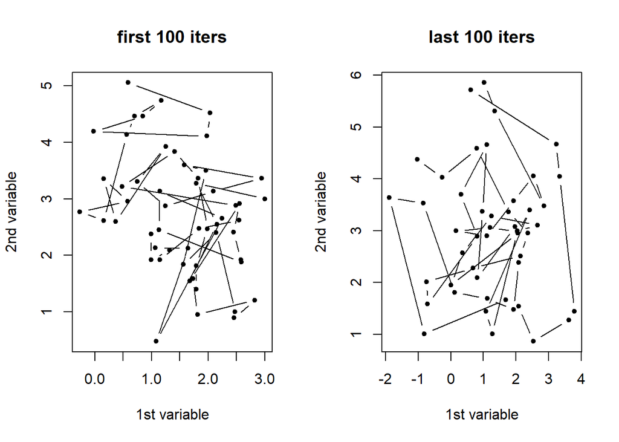

```r
par(mfrow = c(1, 2))
plot(x.norm$chain[1:100, 1], x.norm$chain[1:100, 2], type = "b", pch = 20,
     main = "first 100 iters", xlab = "1st variable", ylab = "2nd variable")
plot(x.norm$chain[9901:10000, 1], x.norm$chain[9901:10000, 2], type = "b",
     pch = 20, main = "last 100 iters", xlab = "1st variable", ylab = "2nd variable")
```

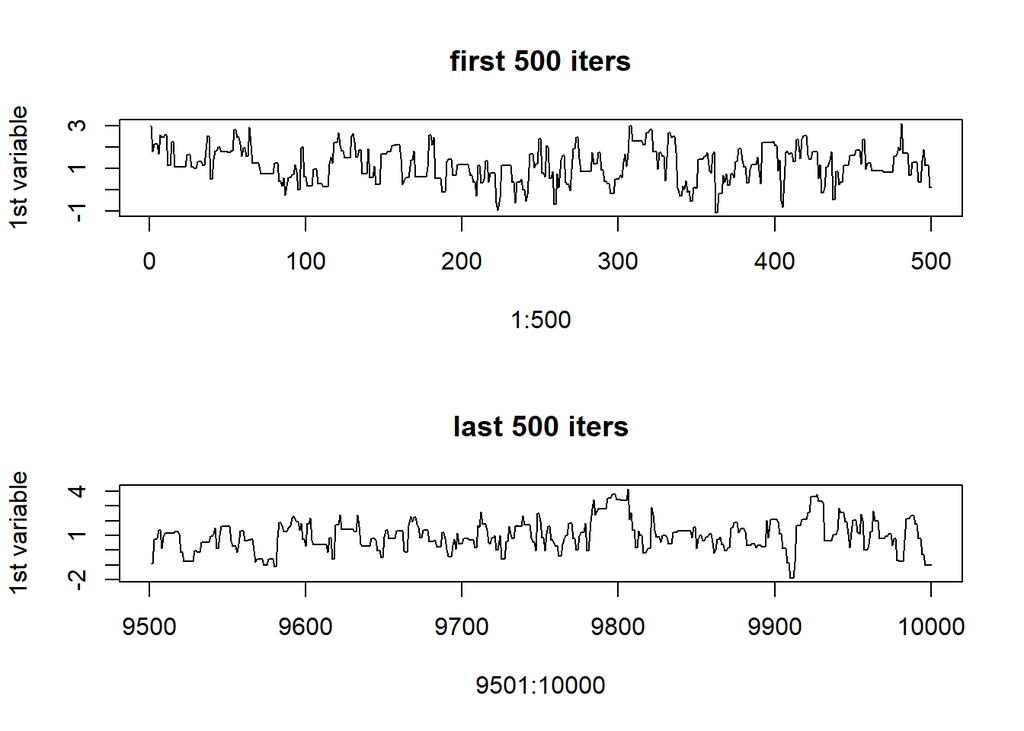

```r
par(mfrow = c(2, 1))
plot(1:500, x.norm$chain[1:500, 1], type = "l", ylab = "1st variable",
     main = "first 500 iters")
plot(9501:10000, x.norm$chain[9501:10000, 1], type = "l", ylab = "1st variable",
     main = "last 500 iters")
```

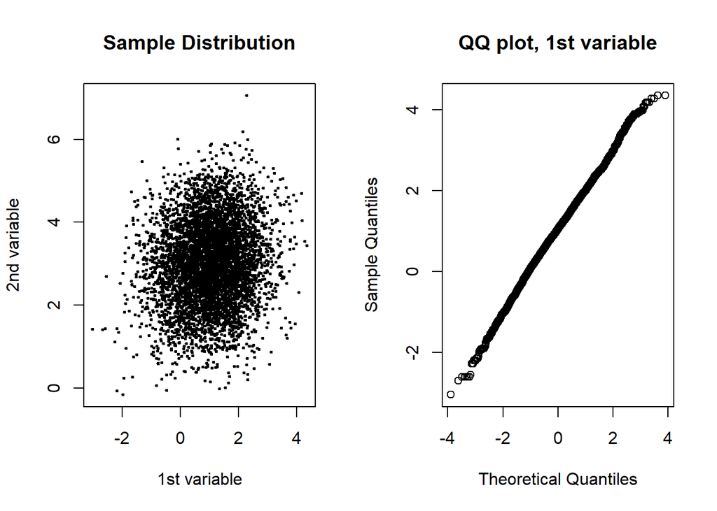

```r
par(mfrow = c(1, 2))
plot(x.norm$chain, pch = 20, cex = 0.5, main = "Sample Distribution",
     xlab = "1st variable", ylab = "2nd variable")
qqnorm(x.norm$chain[, 1], main = "QQ plot, 1st variable")
```

```r
par(mfrow = c(1, 1))
```

可以看到44.46%的候选点被拒绝了，所以这个链条在某种程度上效率很低。样本均值、样本协方差矩阵与理论值较相近。第一个坐标分类的时间图中，有时候样本被拒绝了，对应图中的短横线。从样本分布与目标分布的QQ图可以看出样本分位数和理论分位数近似吻合。

比较不同初值对结果的影响`c(-4, 3), c(1, 3), c(6, 3)`

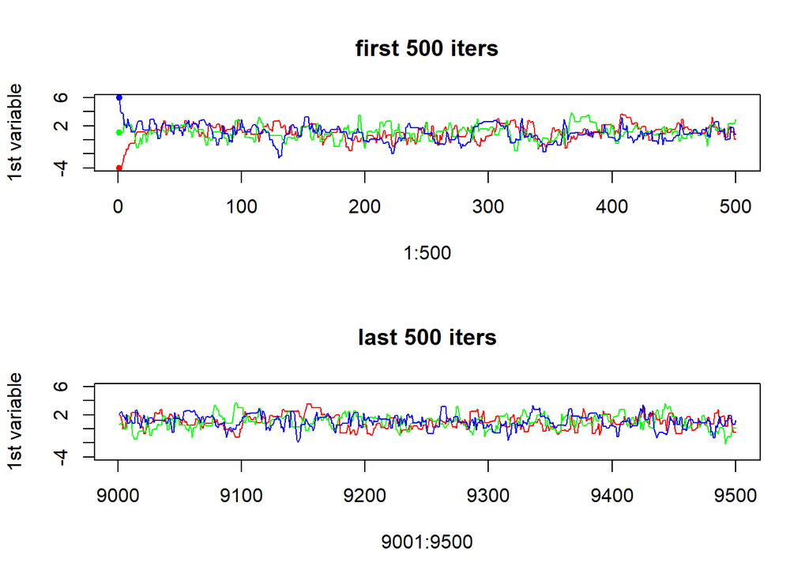

```r
# exploring the results of different initial values
set.seed(1234)
par(mfrow = c(2, 1))
x.norm1 <- mtrp(f, 10000, c(-4, 3), burn = 0)
x.norm2 <- mtrp(f, 10000, c(1, 3), burn = 0)
x.norm3 <- mtrp(f, 10000, c(6, 3), burn = 0)
plot(1:500, x.norm1$chain[1:500, 1], type = "l", col = "red",
     ylab = "1st variable", ylim = c(-4, 6), main = "first 500 iters")
lines(1:500, x.norm2$chain[1:500, 1], col = "green")
lines(1:500, x.norm3$chain[1:500, 1], col = "blue")
points(rep(1, 3), c(-4, 1, 6), col = c("red", "green", "blue"), pch = 20)
plot(9001:9500, x.norm1$chain[9001:9500, 1], type = "l", col = "red",
     ylab = "1st variable", ylim = c(-4, 6), main = "last 500 iters")
lines(9001:9500, x.norm2$chain[9001:9500, 1], col = "green")
lines(9001:9500, x.norm3$chain[9001:9500, 1], col = "blue")
```

```r
par(mfrow = c(1, 1))
```

上图中红、蓝、绿三种颜色分别表示了给定不同初值产生的Markov链的转移情况，可以看到，本例中Markov链很快到达稳态，不同初值对于Markov链的影响可以通过舍去开始的m个样本来消除。

比较不同建议函数（正态分布）的标准差对结果的影响`stepsize in exp(seq(-2, 1, length.out = 4))`

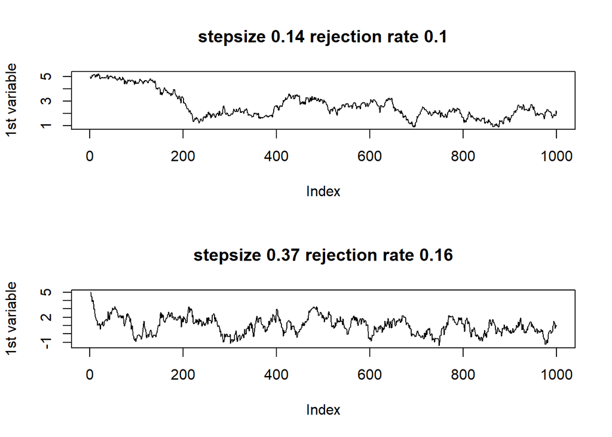

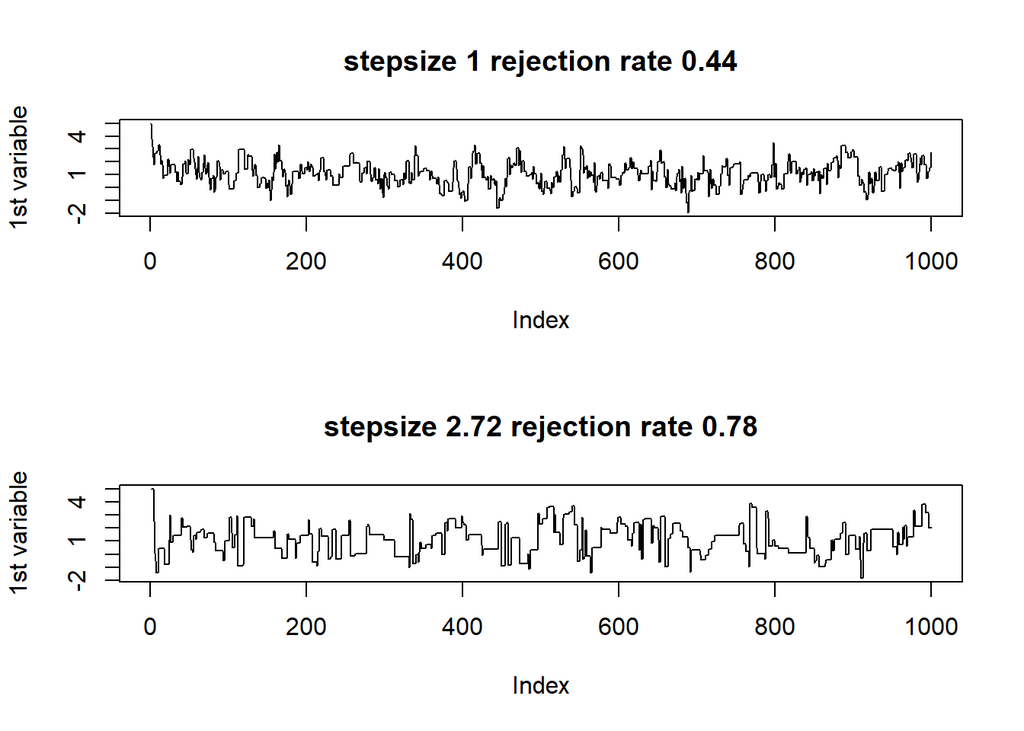

```r
# exploring the results of different stepsizes
set.seed(1234)
par(mfrow = c(2, 1))
for (stepsize in exp(seq(-2, 1, length.out = 4))) {
  x.norm <- mtrp(f, 1000, c(5, 3), stepsize = stepsize, burn = 0)
  plot(
    x.norm$chain[, 1],
    type = "l", ylab = "1st variable",
    main = paste("stepsize", round(stepsize,2), "rejection rate", round(x.norm$alpha,2))
  )
}
```

```r
par(mfrow = c(1, 1))
```

观察上图可以看到该样本生成器的收敛性对正态分布的标准差（尺度参数）的选择非常敏感，当增量的方差非常大（`stepsize` = 2.72）时，Markov链很快收敛，但大多数的候选点都被拒绝了，算法的效率非常低；但若增量的方差过小（`stepsize` = 0.14），经过很长时间才回到期望附近，候选点几乎全部被接受了，所以随机游动Metropolis样本生成器生成了一个几乎类似真正随机游动的链条，这也是非常低效率的；`stepsize`的合理范围是(0.37, 1)，拒绝率既不会太高，也不会有Markov链难以收敛的情况。

### 4.1.2 混合多元正态分布

混合正态分布是典型的多峰分布，本例中通过将两个正态分布的密度函数线性组合作为目标函数，产生10000个样本，分析结果。说明混合正态分布不适合用正态函数做建议分布

给定混合多元正态分布参数`p <- 0.5 mu1 <- c(0, 0) mu2 <- c(6, 6) A1 <- matrix(c(1, 0.1, 0.1, 1), nrow = 2) A2 <- matrix(c(1, -0.1, -0.1, 1), nrow = 2)`

```r
# mixture multivariate normal distribution p*pdf(mu1, A1) + (1-p)*pdf(mu2, A2)
p <- 0.5
mu1 <- c(0, 0)
mu2 <- c(6, 6)
A1 <- matrix(c(1, 0.1, 0.1, 1), nrow = 2)
A2 <- matrix(c(1, -0.1, -0.1, 1), nrow = 2)
A1.det <- det(A1)
A2.det <- det(A2)
A1.inv <- solve(A1)
A2.inv <- solve(A2)
f <- function(x) {
  return(as.vector(
    p * A1.det ^ (-1 / 2) * exp(-0.5 * t(x - mu1) %*% A1.inv %*% (x - mu1)) +
      (1 - p) * A2.det ^ (-1 / 2) * exp(-0.5 * t(x - mu2) %*% A2.inv %*% (x - mu2))
  ))
}
```

产生10000个样本存入`x.mixnorm`

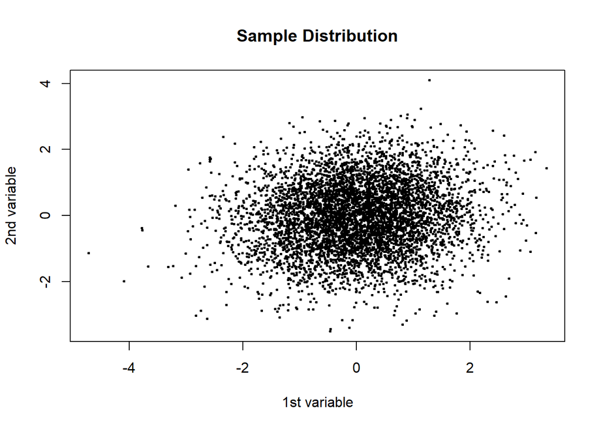

```r
# generating random variates
set.seed(1234)
x.mixnorm <- mtrp(f, 10000, mu1, burn = 0)
plot(x.mixnorm$chain, pch = 20, cex = 0.5, main = "Sample Distribution",
     xlab = "1st variable", ylab = "2nd variable")
```

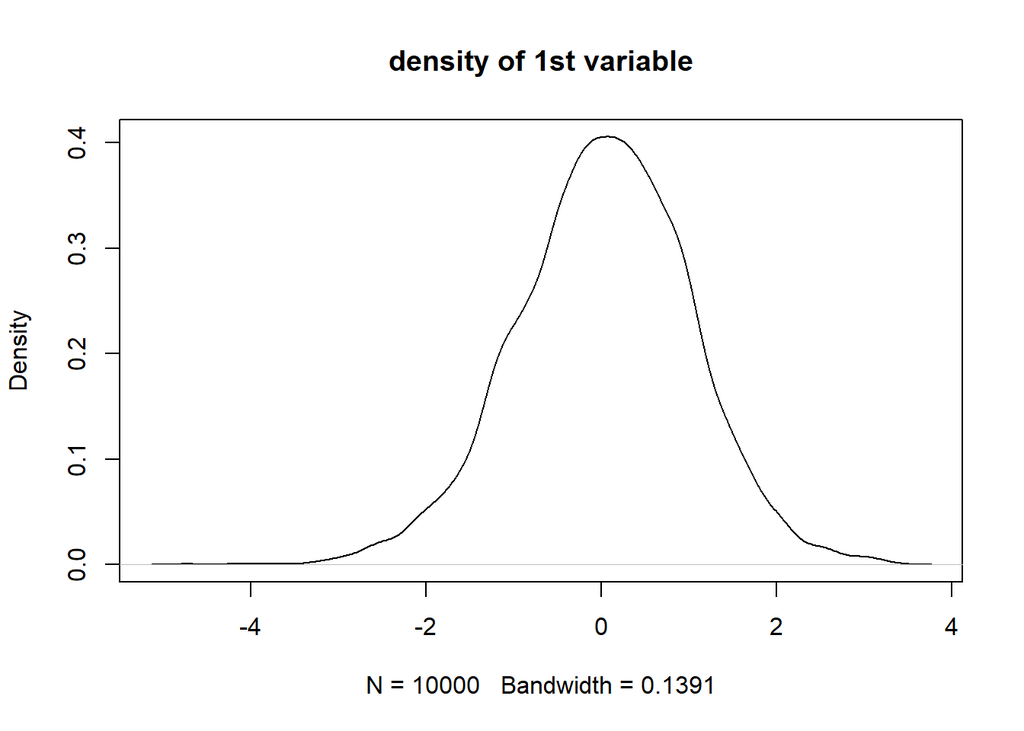

```r
plot(density(x.mixnorm$chain[, 1]), main = "density of 1st variable")
```

观察样本分布图可以看出，这不是二维空间中双峰分布的散点图，更改`stepsize` = 3

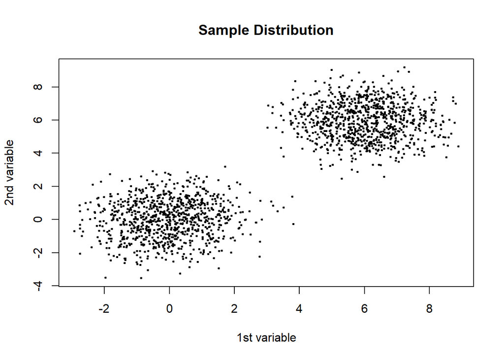

```r
# generating random variates with stepsize = 3
set.seed(1234)
x.mixnorm <- mtrp(f, 10000, mu1, stepsize = 3, burn = 0)
plot(x.mixnorm$chain, pch = 20, cex = 0.5, main = "Sample Distribution",
     xlab = "1st variable", ylab = "2nd variable")
```

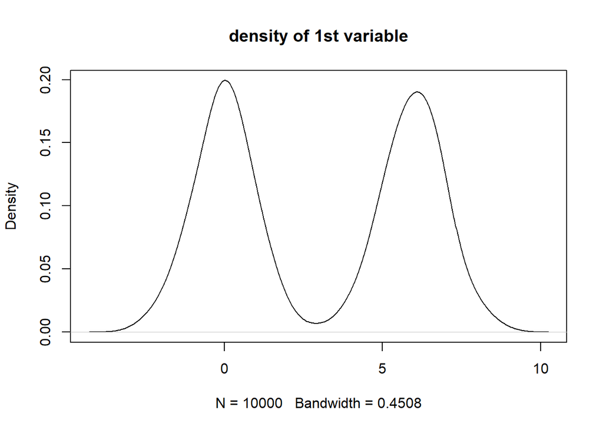

```r
plot(density(x.mixnorm$chain[, 1]), main = "density of 1st variable")
```

观察样本分布图，这次产生的结果符合预期，对结果进行分析

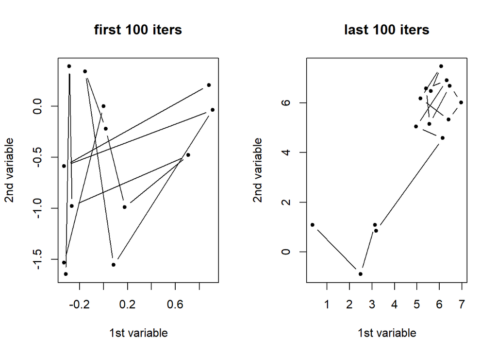

```r
cat("The sample rejection rate is", x.mixnorm$alpha, "\n")
## The sample rejection rate is 0.819
par(mfrow = c(1, 2))
plot(x.mixnorm$chain[1:100, 1], x.mixnorm$chain[1:100, 2], type = "b", pch = 20,
     main = "first 100 iters", xlab = "1st variable", ylab = "2nd variable")
plot(x.mixnorm$chain[9901:10000, 1], x.mixnorm$chain[9901:10000, 2], type = "b",
     pch = 20, main = "last 100 iters", xlab = "1st variable", ylab = "2nd variable")
```

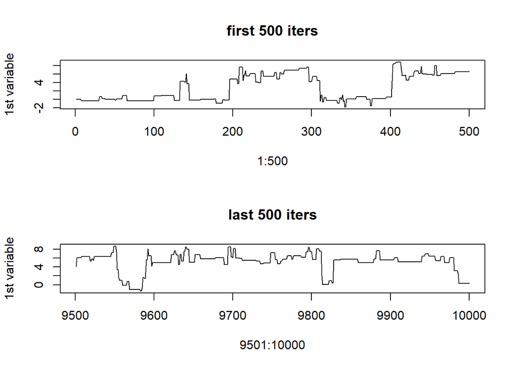

```r
par(mfrow = c(2, 1))
plot(1:500, x.mixnorm$chain[1:500, 1], type = "l", ylab = "1st variable",
     main = "first 500 iters")
plot(9501:10000, x.mixnorm$chain[9501:10000, 1], type = "l", ylab = "1st variable",
     main = "last 500 iters")
```

```r
par(mfrow = c(1, 1))
```

可以看到拒绝率为0.819，极高，说明用此种方法产生目标函数样本的效率非常低，观察时间图可以看出，大部分时间候选点都被拒绝了，Markov链转移速率非常慢。

选择小的方差，会造成样本结果的严重错误，而选择较大的方差，拒绝率又相当高，实际上，这与高维的稀疏性有关，维度越高，Markov链的拒绝率就会越高，之后要讨论的Gibbs样本分类器能很好地针对高维目标分布问题提高效率

通过上例可以看到，建议分布不是任意选取就能产生很好的效果的，需要综合给定的目标分布以及多种因素来考虑，比如，以正态分布做建议函数的随机游动Metropolis样本生成器就不适合混合多元正态分布

## 4.2 情形2 `mtrp_exp`

对目标函数的支撑集为半空间的情形（$X\subset[a_1,+\infty)\times\cdots\times[a_n,+\infty)$），编写了函数`mtrp_exp`，该函数使用指数分布做建议分布，使用独立性样本生成器来生成样本。注意建议分布与上一状态取值无关，即$f(Y|X)=f(Y)$

以下3个例子的目标函数均来自 Project 第4题

指数分布的左截尾，支撑集为$[1,+\infty)$

```r
# the Exp(1) distribution left-truncated at 1 (i.e., with support [1,∞))
# with pdf f(x) = exp(1 - x)
f <- function(x){
  ifelse(x >= 1, return(exp(-x)), 0)
}
```

使用函数`mtrp`产生10000个样本

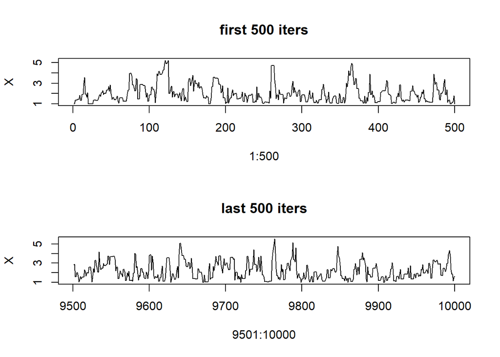

```r
# generating random variates
set.seed(1234)
x.exp1 <- mtrp(f, 10000, 1, burn = 0)
cat("The sample rejection rate is", x.exp1$alpha, "\n")
## The sample rejection rate is 0.3119
par(mfrow = c(2, 1))
plot(1:500, x.exp1$chain[1:500], type = "l",
     main = "first 500 iters", ylab = "X")
plot(9501:10000, x.exp1$chain[9501:10000], type = "l",
     main = "last 500 iters", ylab = "X")
```

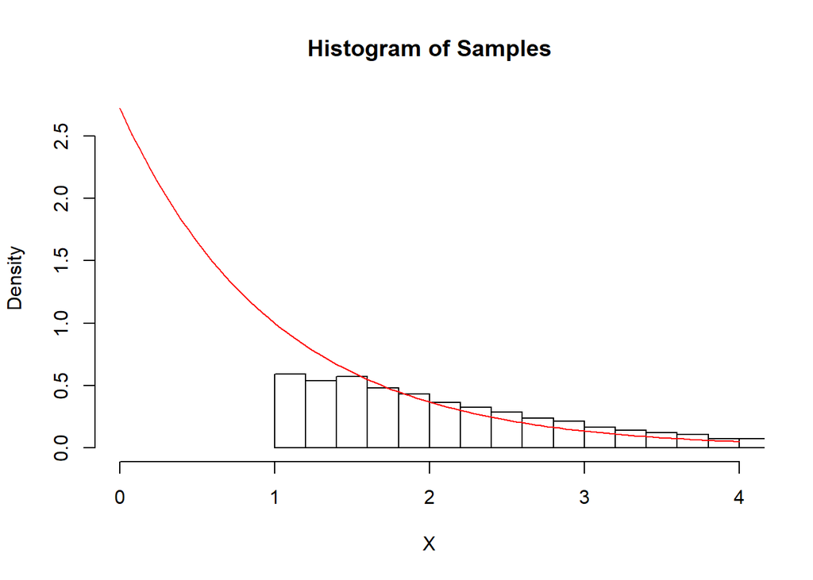

```r
par(mfrow = c(1, 1))
hist(x.exp1$chain, freq = FALSE, breaks = 30,
     main = "Histogram of Samples",
     xlab = "X", xlim = c(0,4), ylim = c(0,  exp(1)))
curve(exp(1 - x), col = "red", add = TRUE)
```

使用函数`mtrp_exp`产生10000个样本

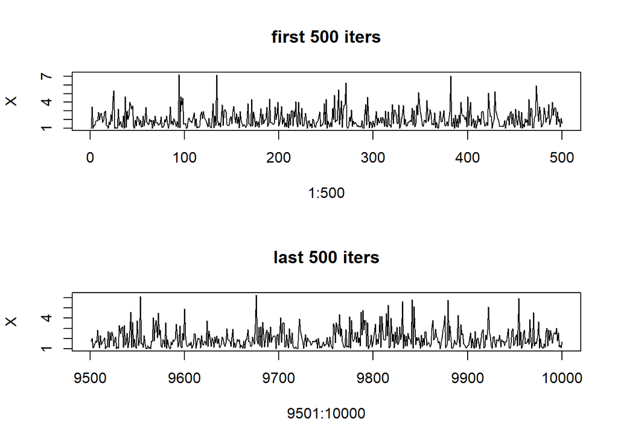

```r
# generating random variates using function `mtrp_exp`
set.seed(1234)
x.exp1 <- mtrp_exp(f, 10000, 1, a = 1, burn = 0)
cat("The sample rejection rate is", x.exp1$alpha, "\n")
## The sample rejection rate is 0
par(mfrow = c(2, 1))
plot(1:500, x.exp1$chain[1:500], type = "l",
     main = "first 500 iters", ylab = "X")
plot(9501:10000, x.exp1$chain[9501:10000], type = "l",
     main = "last 500 iters", ylab = "X")
```

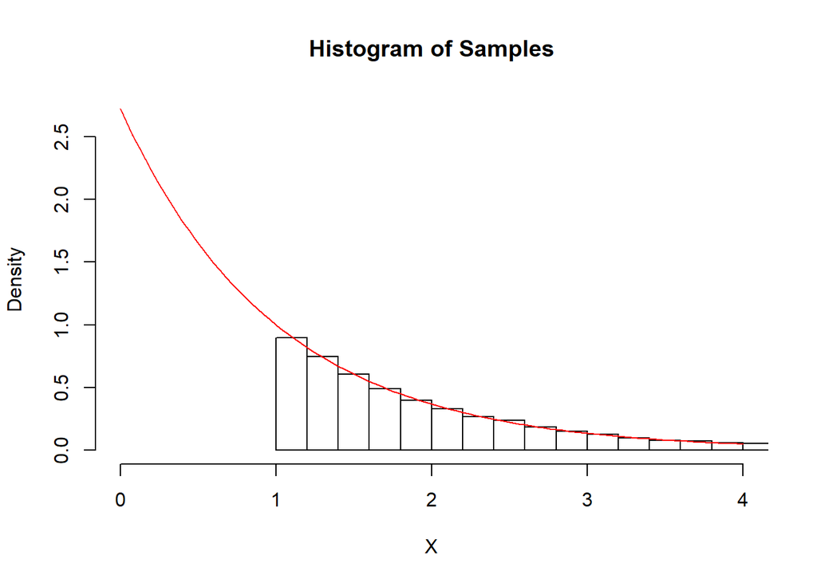

```r
par(mfrow = c(1, 1))
hist(x.exp1$chain, freq = FALSE, breaks = 50,
     main = "Histogram of Samples",
     xlab = "X", xlim = c(0,4), ylim = c(0,  exp(1)))
curve(exp(1 - x), col = "red", add = TRUE)
```

观察上述结果，发现使用正态分布做建议分布的随机游动Metropolis样本生成器（`mtrp`）效率不如使用指数分布做建议分布的独立性样本生成器（`mtrp_exp`），前者拒绝率为0.3119，而后者为0。而且观察上述方法产生样本的直方图与理论（红线）对比，发现`mtrp_exp`产生的样本与理论更接近，因此，针对与指数分布相近的目标分布，使用`mtrp_exp`更为合适

## 4.3 情形3 `mtrp_unif`

对目标函数的支撑集为有限的情形（$X\subset[a_1,b_1]\times\cdots\times[a_n,b_n]$），编写了函数`mtrp_unif`，该函数使用均匀分布做建议分布，使用独立性样本生成器来生成样本。

指数分布的右截尾，支撑集为$[0,1]$

```r
# the Exp(1) distribution right-truncated at 1 (i.e., with support [0,1]
# with pdf f(x) = exp(1 - x) / (e - 1)
f <- function(x){
  ifelse(x >= 0 && x <=1, return(exp(-x)), 0)
}
```

使用函数`mtrp`产生10000个样本

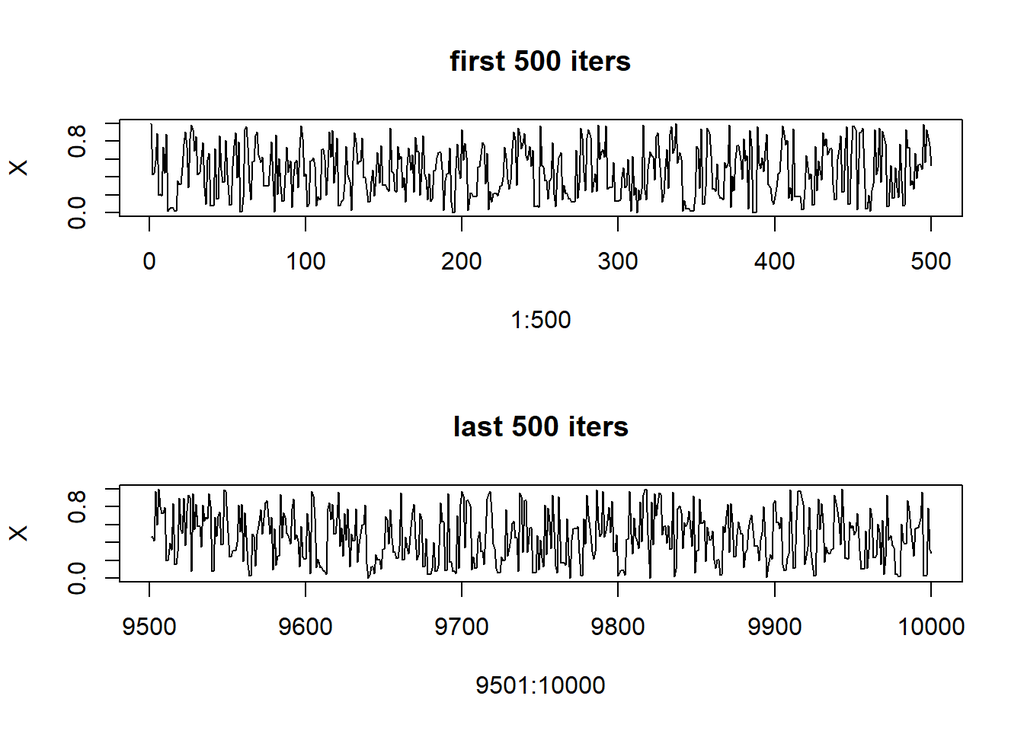

```r
# generating random variates
set.seed(1234)
x.exp2 <- mtrp(f, 10000, 1, burn = 0)
cat("The sample rejection rate is", x.exp2$alpha, "\n")
## The sample rejection rate is 0.1522
par(mfrow = c(2, 1))
plot(1:500, x.exp2$chain[1:500], type = "l",
     main = "first 500 iters", ylab = "X")
plot(9501:10000, x.exp2$chain[9501:10000], type = "l",
     main = "last 500 iters", ylab = "X")
```

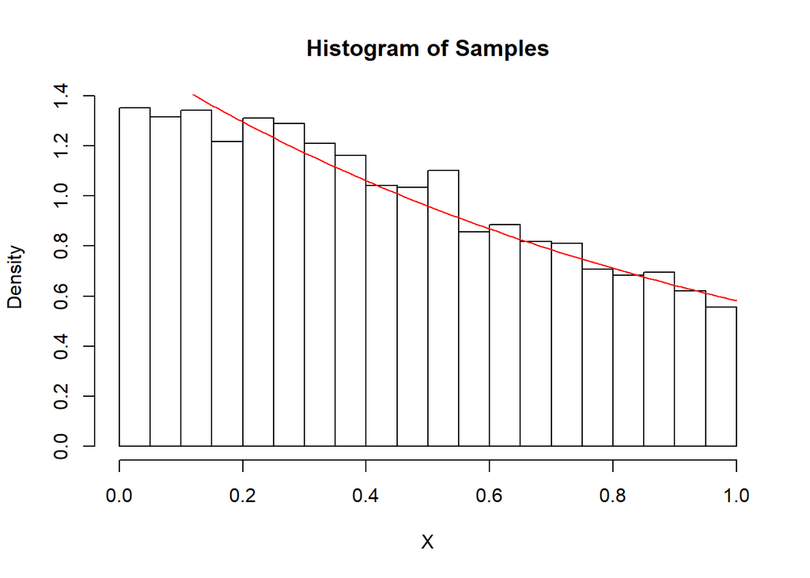

```r
par(mfrow = c(1, 1))
hist(x.exp2$chain, freq = FALSE, main = "Histogram of Samples", xlab = "X")
curve(exp(1 - x) / (exp(1) - 1), from = 0, to = 1, col = "red", add = TRUE)
```

使用函数`mtrp_unif`产生10000个样本

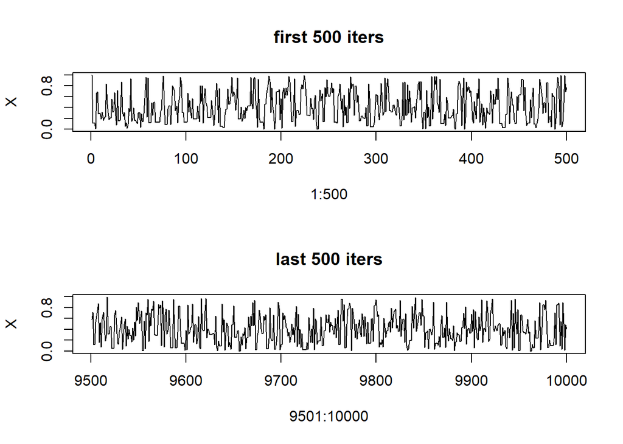

```r
# generating random variates using function `mtrp_unif`
set.seed(1234)
x.exp2 <- mtrp_unif(f, 10000, 1, a = 0, b = 1, burn = 0)
cat("The sample rejection rate is", x.exp2$alpha, "\n")
## The sample rejection rate is 0.1573
par(mfrow = c(2, 1))
plot(1:500, x.exp2$chain[1:500], type = "l",
     main = "first 500 iters", ylab = "X")
plot(9501:10000, x.exp2$chain[9501:10000], type = "l",
     main = "last 500 iters", ylab = "X")
```

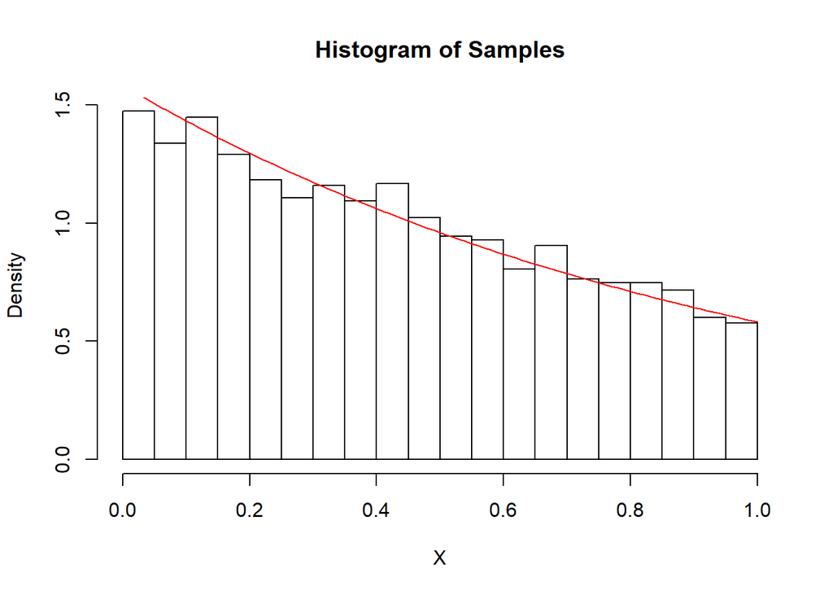

```r
par(mfrow = c(1, 1))
hist(x.exp2$chain, freq = FALSE, main = "Histogram of Samples", xlab = "X")
curve(exp(1 - x) / (exp(1) - 1), from = 0, to = 1, col = "red", add = TRUE)
```

观察上述结果，发现使用正态分布做建议分布的随机游动Metropolis样本生成器（`mtrp`）效率与使用均匀分布做建议分布的独立性样本生成器（`mtrp_unif`）相近，前者拒绝率为0.1522，而后者为0.1573。但观察样本直方图与理论对比发现，`mtrp_unif`产生的样本与理论更接近（在$x=0.5$附近），因此，针对有限区间的目标分布，`mtrp_unif`是更好的选择

## 4.4 一个例子：Pareto分布

指数-Gamma混合分布，假设$\Lambda$服从$\mathrm{Gamma}(r,β)$，$X$服从$\mathrm{Exp}(\Lambda)$，也就是说，$X|(Λ = λ) ∼ f_X(x|\lambda)= λe^{−λx}$，可以通过对联合密度函数积分得到$X$的pdf为$f_X(x)=\frac{r\beta^r}{(x + \beta)^{r+1}}$

### 4.4.1 r = 4, beta = 2

方法1：产生$(X,\Lambda)$的联合分布，抽取第一个坐标分量获得$X$的分布

```r
# the Exponential-Gamma mixture (Suppose that the rate parameter Λ has Gamma (
# r,β ) distribution and X has Exp(Λ) distribution. That is, X|Λ = λ ∼ f X (x|λ)
# = λe −λy .) with r = 4 and β = 2.with pdf f(x) = r * β^r / (x + β)^{r+1}
# suppose we don't know the expression of pdf f(x), however, the joint pdf
# f(x, λ) = f (x|λ) * f(λ) = λ ^ r * e^{-(x + β)*λ}is clear, so samples (x, λ) can be generated.
r <- 4
beta <- 2
f <- function(x){
  ifelse(x[1] >= 0 && x[2] >=0, x[2]^r * exp(-x[2] * (x[1]+beta)), 0)
}
```

使用函数`mtrp`产生10000个样本

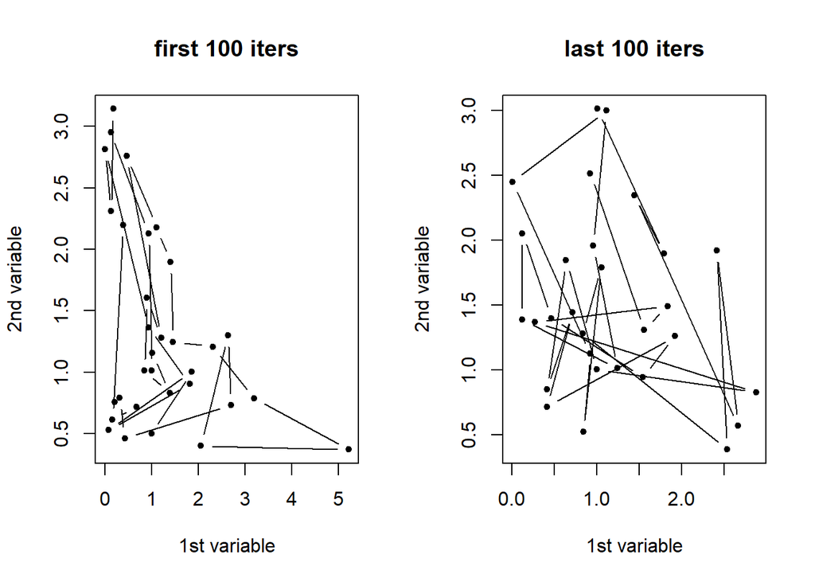

```r
# generating random variates
set.seed(1234)
x.pareto0 <- mtrp(f, 10000, c(1, 0.5), stepsize = c(2, 1), burn = 0)
cat("The sample rejection rate is", x.pareto0$alpha, "\n")
## The sample rejection rate is 0.7195
par(mfrow = c(1, 2))
plot(x.pareto0$chain[1:100, 1], x.pareto0$chain[1:100, 2], type = "b", pch = 20,
     main = "first 100 iters", xlab = "1st variable", ylab = "2nd variable")
plot(x.pareto0$chain[9901:10000, 1], x.pareto0$chain[9901:10000, 2], type = "b", pch = 20,
     main = "last 100 iters", xlab = "1st variable", ylab = "2nd variable")
```

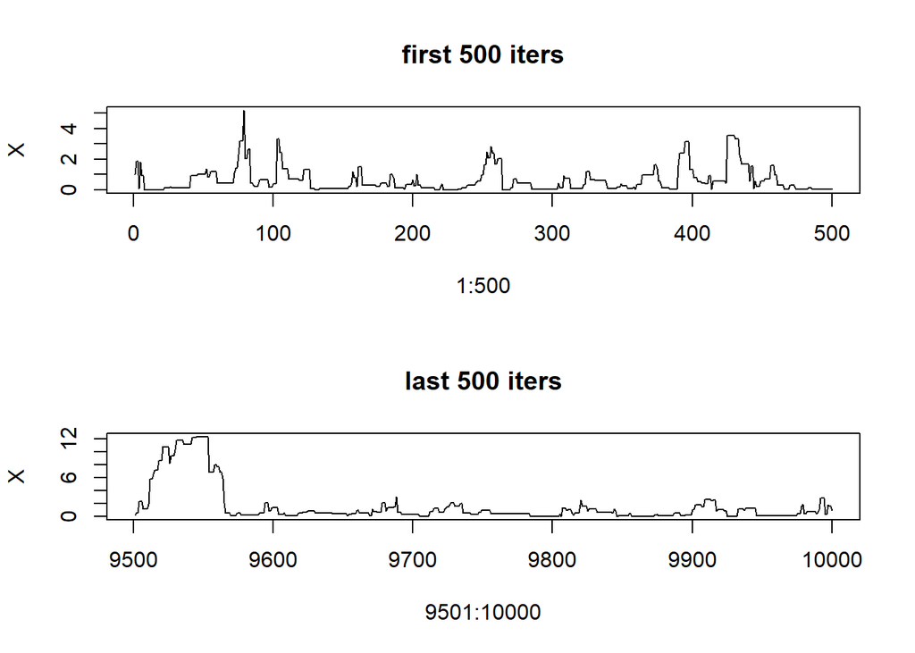

```r
par(mfrow = c(2, 1))
plot(1:500, x.pareto0$chain[1:500, 1], type = "l",
     main = "first 500 iters", ylab = "X")
plot(9501:10000, x.pareto0$chain[9501:10000, 1], type = "l",
     main = "last 500 iters", ylab = "X")
```

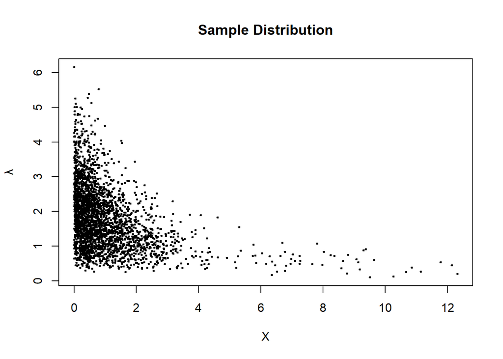

```r
par(mfrow = c(1, 1))
plot(x.pareto0$chain, pch = 20, cex = 0.5, main = "Sample Distribution",
     xlab = "X", ylab = "λ")
```

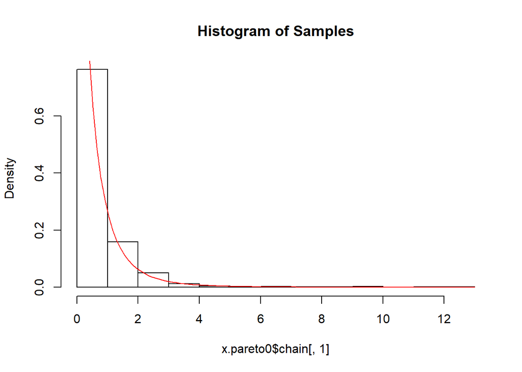

```r
hist(x.pareto0$chain[, 1], freq = FALSE, main = "Histogram of Samples")
curve(r * beta^r * (x + beta)^(-(r+1)), from = 0, col = "red", add = TRUE)
```

使用函数`mtrp_exp`产生10000个样本

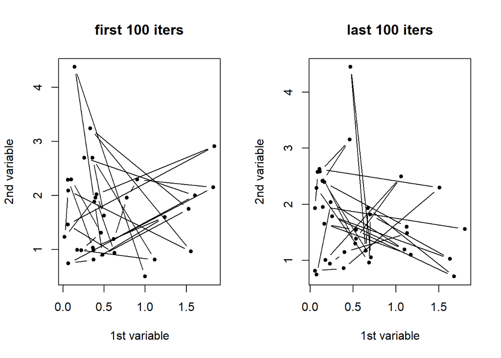

```r
# generating random variates using `mtrp_exp`
set.seed(1234)
x.pareto0 <- mtrp_exp(f, 10000, c(1, 0.5), rate = c(2, 1), burn = 0)
cat("The sample rejection rate is", x.pareto0$alpha, "\n")
## The sample rejection rate is 0.6612
par(mfrow = c(1, 2))
plot(x.pareto0$chain[1:100, 1], x.pareto0$chain[1:100, 2], type = "b", pch = 20,
     main = "first 100 iters", xlab = "1st variable", ylab = "2nd variable")
plot(x.pareto0$chain[9901:10000, 1], x.pareto0$chain[9901:10000, 2], type = "b", pch = 20,
     main = "last 100 iters", xlab = "1st variable", ylab = "2nd variable")
```

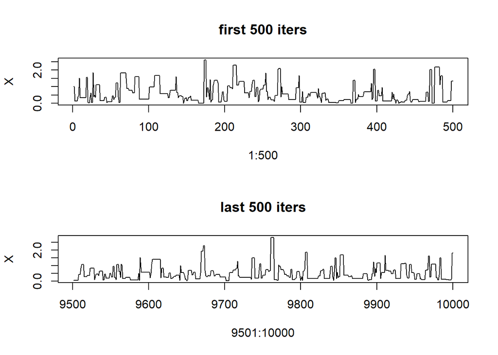

```r
par(mfrow = c(2, 1))
plot(1:500, x.pareto0$chain[1:500, 1], type = "l",
     main = "first 500 iters", ylab = "X")
plot(9501:10000, x.pareto0$chain[9501:10000, 1], type = "l",
     main = "last 500 iters", ylab = "X")
```

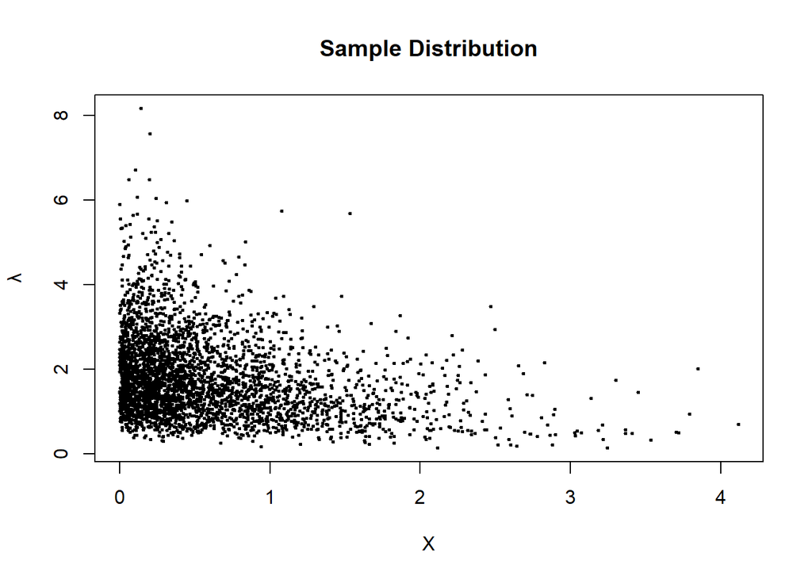

```r
par(mfrow = c(1, 1))
plot(x.pareto0$chain, pch = 20, cex = 0.5, main = "Sample Distribution",
     xlab = "X", ylab = "λ")
```

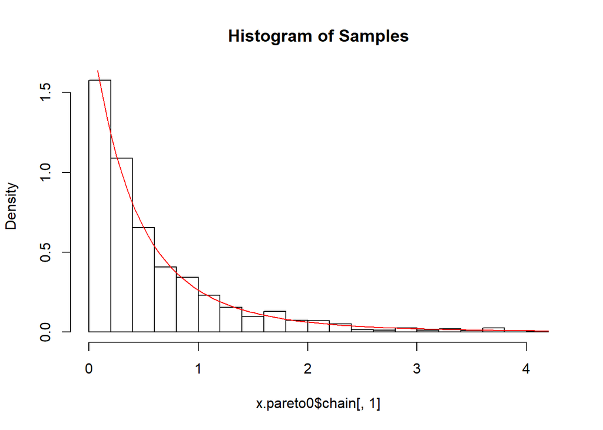

```r
hist(x.pareto0$chain[, 1], freq = FALSE, main = "Histogram of Samples")
curve(r * beta^r * (x + beta)^(-(r+1)), from = 0, col = "red", add = TRUE)
```

下面考虑对X的边际分布，pdf为$f_X(x)=\frac{r\beta^r}{(x + \beta)^{r+1}}$

```r
# the Exponential-Gamma mixture (Suppose that the rate parameter Λ has Gamma (
# r,β ) distribution and X has Exp(Λ) distribution. That is, X|Λ = λ ∼ f_X (x|λ)
# = λe^{−λy}.) with r = 4 and β = 2. with pdf f(x) = r * β^r / (x + β)^{r+1},
# specially, it is f(x) = 64 / (x + 2)^5
r <- 4
beta <- 2
f <- function(x){
  ifelse(x >= 0, (x + beta)^(-(r+1)), 0)
}
```

使用函数`mtrp_exp`产生10000个样本

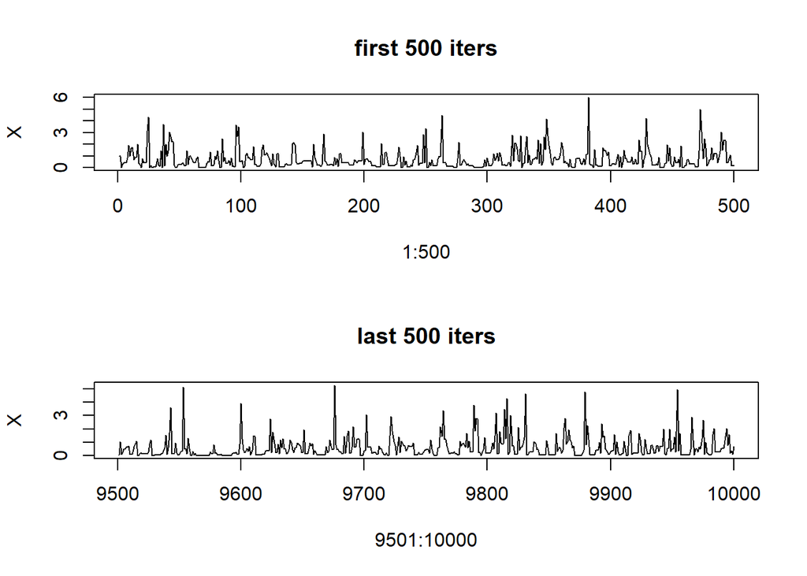

```r
# generating random variates using function `mtrp_exp`
set.seed(1234)
x.pareto <- mtrp_exp(f, 10000, 1, burn = 0)
cat("The sample rejection rate is", x.pareto$alpha, "\n")
## The sample rejection rate is 0.274
par(mfrow = c(2, 1))
plot(1:500, x.pareto$chain[1:500], type = "l",
     main = "first 500 iters", ylab = "X")
plot(9501:10000, x.pareto$chain[9501:10000], type = "l",
     main = "last 500 iters", ylab = "X")
```

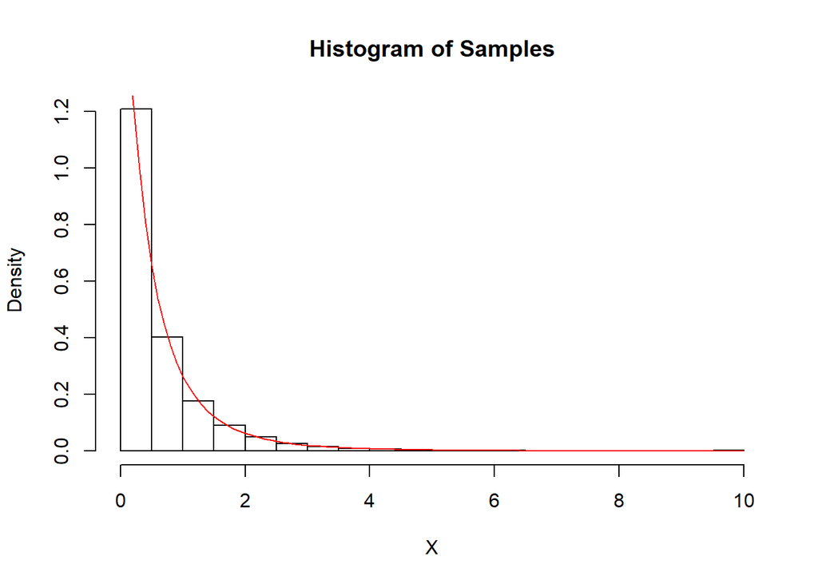

```r
par(mfrow = c(1, 1))
hist(x.pareto$chain, freq = FALSE, main = "Histogram of Samples", xlab = "X")
curve(r * beta^r * (x + beta)^(-(r+1)), from = 0, col = "red", add = TRUE)
```

拒绝率仅为0.274，样本分布图与理论吻合地较好

### 4.4.2 r = 1, beta = 2

改变$r$的值，$\beta$保持不变

```r
# If we change r from 4 to 1
r <- 1
beta <- 2
f <- function(x){
  ifelse(x >= 0, (x + beta)^(-(r+1)), 0)
}
```

使用函数`mtrp_exp`产生10000个样本

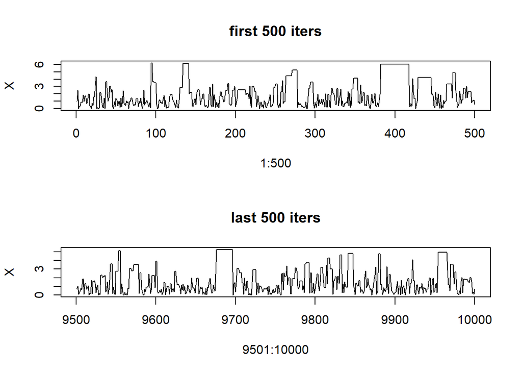

```r
# generating random variates using function `mtrp_exp`
set.seed(1234)
x.pareto <- mtrp_exp(f, 10000, 1, burn = 0)
cat("The sample rejection rate is", x.pareto$alpha, "\n")
## The sample rejection rate is 0.323
par(mfrow = c(2, 1))
plot(1:500, x.pareto$chain[1:500], type = "l",
     main = "first 500 iters", ylab = "X")
plot(9501:10000, x.pareto$chain[9501:10000], type = "l",
     main = "last 500 iters", ylab = "X")
```

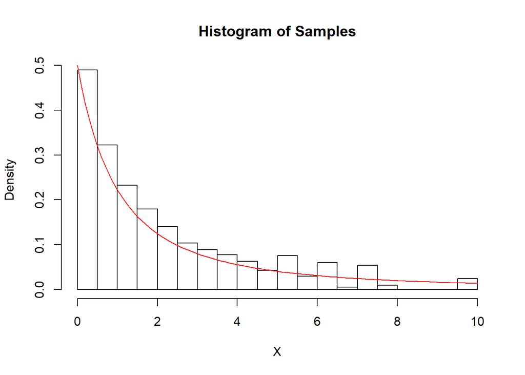

```r
par(mfrow = c(1, 1))
hist(x.pareto$chain, freq = FALSE, main = "Histogram of Samples", xlab = "X")
curve(r * beta^r * (x + beta)^(-(r+1)), from = 0, col = "red", add = TRUE)
```

观察Markov链时间图，发现在前500次和后500次循环中均出现了长横线，而且对应的x值越大，长横线越长，这表现为在直方图中的$(5,10)$之内的异常分布，这是由于指数分布与目标函数不相近造成的，由于指数分布的pdf相比目标函数下降速度非常快，在上一状态X值很大的情形下$\alpha(X,Y)=\min\{1,\frac{f(Y)g(X)}{f(X)g(Y)}\}\approx\frac{g(X)}{g(Y)}\ll1$，即接受率非常低，因此可能会造成该点的概率异常得高。